# Distribution of lines through a pixel

In an MCMC or a hillclimbing algorithm, $b$ would be varied incrementally and error recomputed. One possibility is to vary a single element of $b$ at a time, (e.g., Gibbs sampling in MCMC.) If $\Delta b$ represents the change in $b$ and $\eta'$ the new error,$S(b + \Delta b) = ToF + \eta', \\ Sb + S\Delta b = ToF + \eta', \\ \eta' = S\Delta b + (Sb - ToF), \\ \eta' = S\Delta b + \eta.$

Thus, $S\Delta b$ represents the change in putative error. If only a single element of $b$ were changed per step of an algorithm, the computation of $S\Delta b$ would involve only one column of $S$ and only those rows of $S$ corresponding to paths which intersect the pixel corresponding to the changed element of $b$. It is therefore of some interest to know how many paths intersect an average pixel and how that number increases with $n.$

We estimate the distribution–mean, standard deviation, and histogram–of such numbers for $n=5, 6, 7$ (32x32, 64x64, 128x128, pixels respectively,) by choosing 1000 pixels at random and calculating the number of paths which intersect each one.

Roughly, the mean is $1.25*2^n$ and the standard deviation is $45\%$ of the mean.

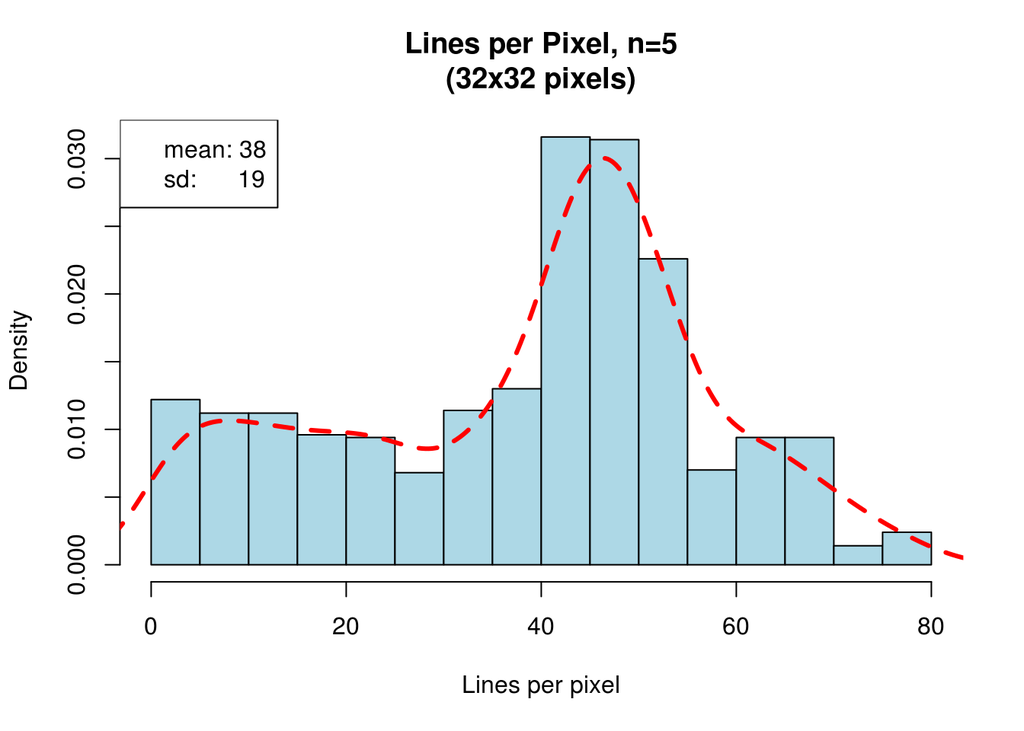

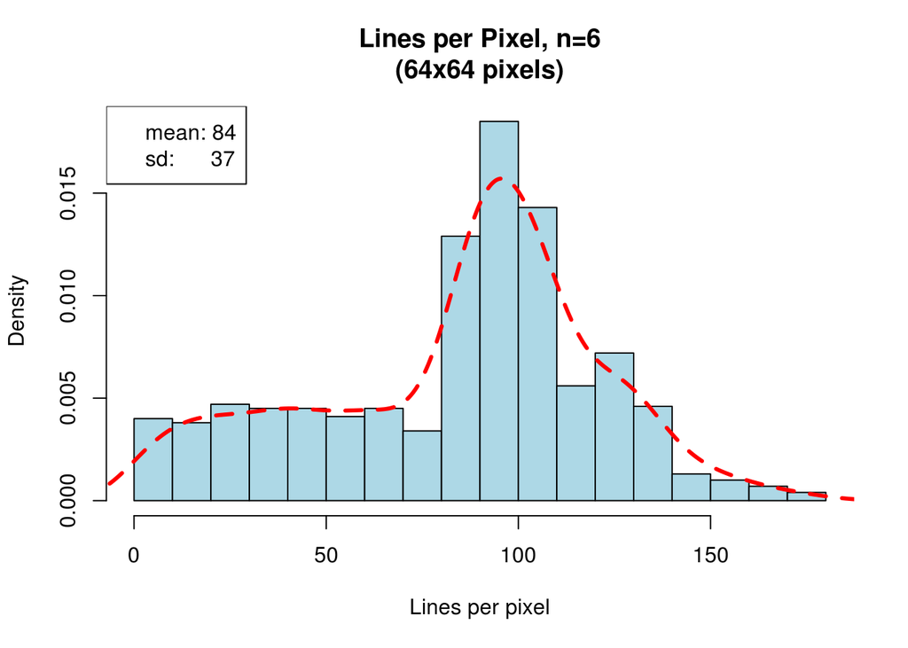

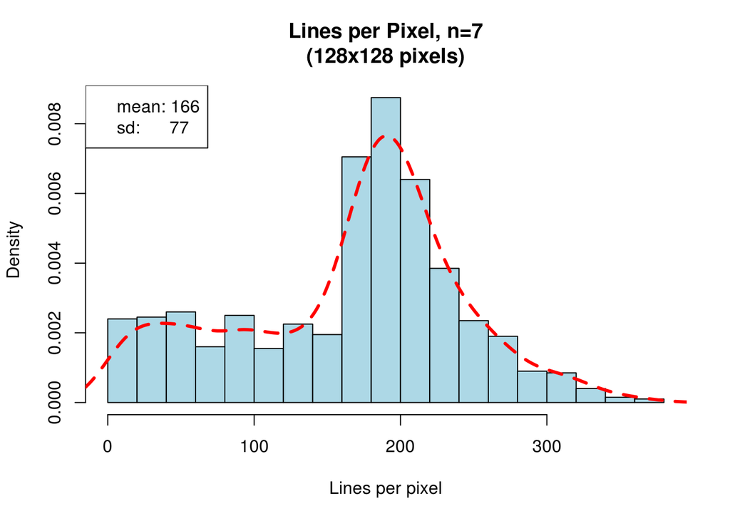